# Lab 4: Graphical interpretation of LMs: Answer Key

Eric Parajon

Today’s lab will focus on graphical interpretation of LMs using a variety of R tools.

Don’t forget to set your working directory!

```r
setwd()
```

# Part 1: Ggplot visualizations

Lets begin by returning to the mtcars data set and creating a basic plot of Displacement vs mpg.

```r
carsplot <- ggplot(data = mtcars, aes(x = disp, y = mpg)) +
  geom_point(aes(colour = cyl), size = 2) +
  labs(title = "Car Stuff", x = "Displacement (cc)", y = "Miles per Gallon") +
  scale_colour_continuous(name = "Cylinders")+
  theme_bw()

#One method for saving plots:
#pdf("Plot1.pdf")
#carsplot
#dev.off()

#Where do these plots go?!

#Unique to ggplot:
#ggsave("Plot1a.pdf") #can edit image sizes as well
```

- Okay great, but what if we wanted to plot the linear relationship between our x and y?

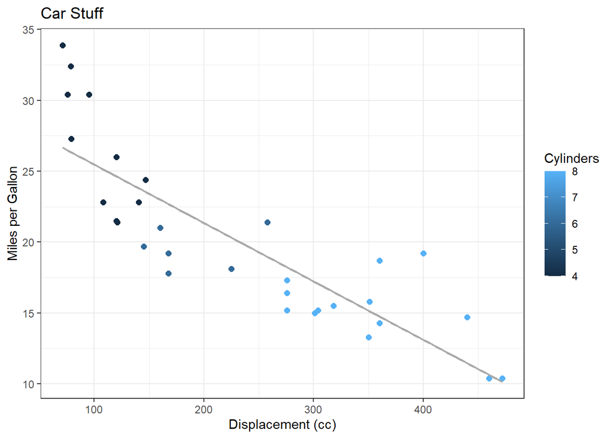

```r
carsplot + geom_smooth(method = "lm", se = FALSE,
                       color = "darkgrey", linewidth = 0.75)
```

```r
#geom_smooth is for fitted lines.
#se=TRUE plots confidence intervals
#We can adjust the color and size of the line plotted.
#Also, note that we just added a layer over carsplot - did we change the carsplot object itself?
```

- Right now, we’re using color as the aesthetic mapped to a specific explanatory variable (color represents the number of cylinders). We can play around with this:

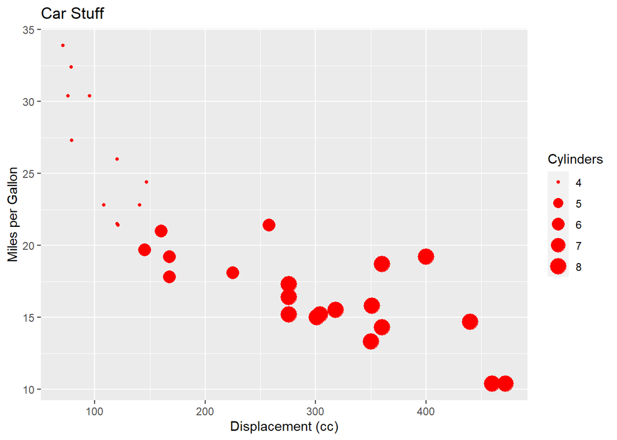

```r
ggplot(data = mtcars, aes(x = disp, y = mpg)) +
  geom_point(aes(size = cyl), colour = "red") +
  labs(title = "Car Stuff", x = "Displacement (cc)", y = "Miles per Gallon") +
  scale_size_continuous(name = "Cylinders")
```

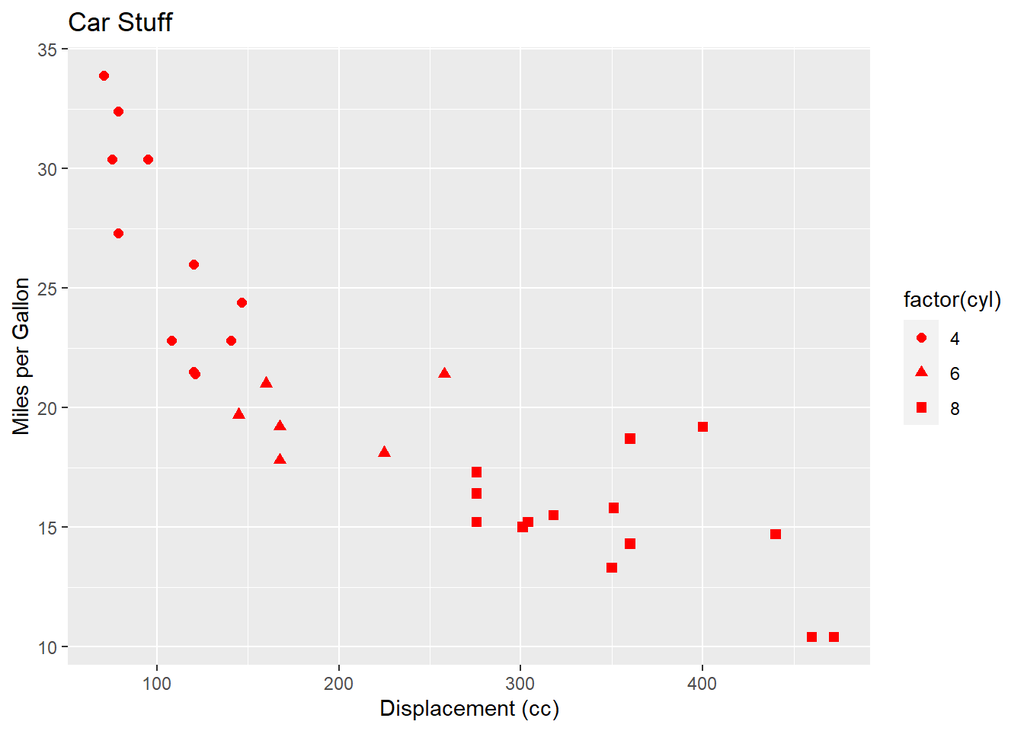

```r
ggplot(data=mtcars, aes(x = disp, y = mpg)) +
  geom_point(aes(shape = factor(cyl)), colour = "red", size = 2) +
  labs(title = "Car Stuff", x = "Displacement (cc)", y = "Miles per Gallon") +
  scale_size_continuous(name = "Cylinders")
```

- What are the benefits/drawbacks of each of these strategies? Think about how well the plot communicates information about the types of variables plotted as well as the relationship between them.
- The above are great places to start out visualizing any potential relationships between your variables.

## Themes

- As you’ve hopefully seen ggplot is highly customization. One way to standardize your graphs and avoid repeating your code to control ancillary parameters (e.g. color palettes, axes labels, etc.) is to use a ggplot() theme that includes bundles of code. This is what we were doing using theme_bw() above.
- You can also create custom themes yourself!

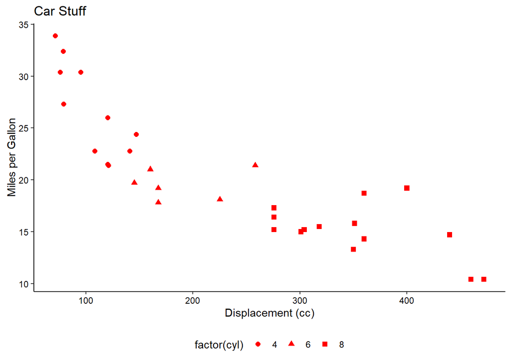

```r
#Here is a theme I use often

plot_theme = theme(text = element_text(size=11),  #set text size to 11
                   panel.grid.minor = element_blank(), #these next two lines set the grid lines to null
                   panel.grid.major = element_blank(),
                   panel.background = element_blank(),#these lines make the background of the plot blank
                   plot.background = element_rect(fill = "transparent",colour = NA),
                   axis.text = element_text(color="black"), #setting axis text to black
                   axis.line = element_line(colour = "black"),#setting axis lines to black
                   strip.text.y = element_text(angle = 0), axis.title.y = element_text(angle=90, hjust=.5, vjust=.5),#adjusting the angle of text
                   axis.title = element_text(lineheight=1.1), #increasing height of axis title
                   legend.position = "bottom",  #Placing the legend at the bottom of the figure
                   legend.key = element_rect(colour = "transparent",  fill = "transparent") #setting legend to transparent
)


#Using the theme
ggplot(data=mtcars, aes(x = disp, y = mpg)) +
  geom_point(aes(shape = factor(cyl)), colour = "red", size = 2) +
  labs(title = "Car Stuff", x = "Displacement (cc)", y = "Miles per Gallon") +
  scale_size_continuous(name = "Cylinders") +
  plot_theme
```

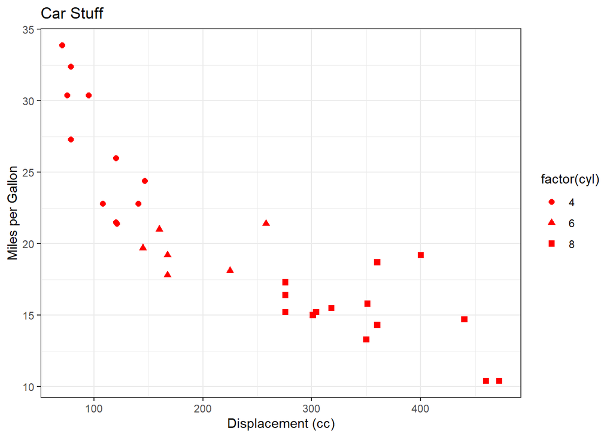

```r
#As you can see there are tons of options that you can set yourself. Alternatively you can use existing gplot_themes. Here are some of the most popular
#bw
ggplot(data=mtcars, aes(x = disp, y = mpg)) +
  geom_point(aes(shape = factor(cyl)), colour = "red", size = 2) +
  labs(title = "Car Stuff", x = "Displacement (cc)", y = "Miles per Gallon") +
  scale_size_continuous(name = "Cylinders") +
  theme_bw()
```

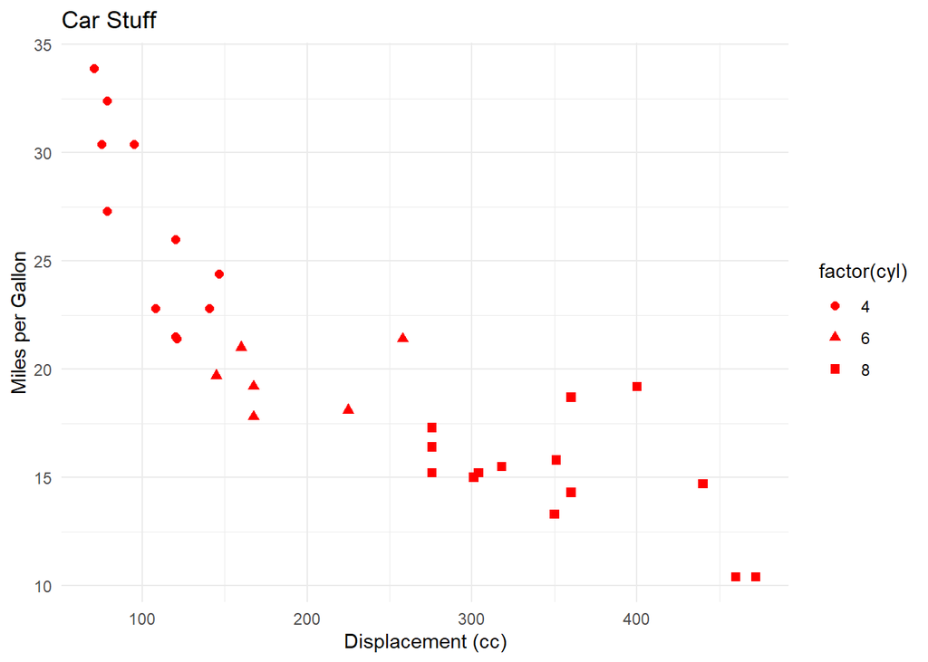

```r
#minimal
ggplot(data=mtcars, aes(x = disp, y = mpg)) +
  geom_point(aes(shape = factor(cyl)), colour = "red", size = 2) +
  labs(title = "Car Stuff", x = "Displacement (cc)", y = "Miles per Gallon") +
  scale_size_continuous(name = "Cylinders") +
  theme_minimal()
```

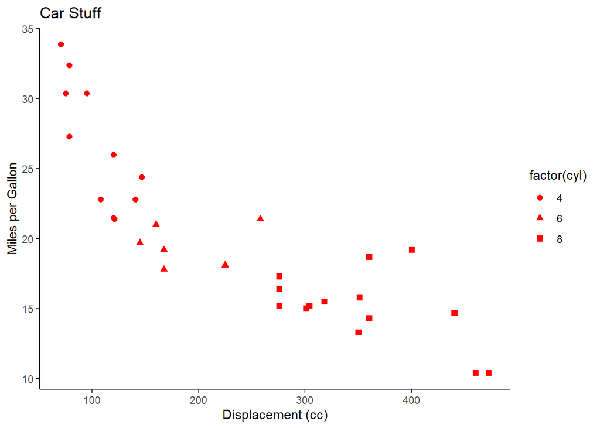

```r
#classic
ggplot(data=mtcars, aes(x = disp, y = mpg)) +
  geom_point(aes(shape = factor(cyl)), colour = "red", size = 2) +
  labs(title = "Car Stuff", x = "Displacement (cc)", y = "Miles per Gallon") +
  scale_size_continuous(name = "Cylinders") +
  theme_classic()
```

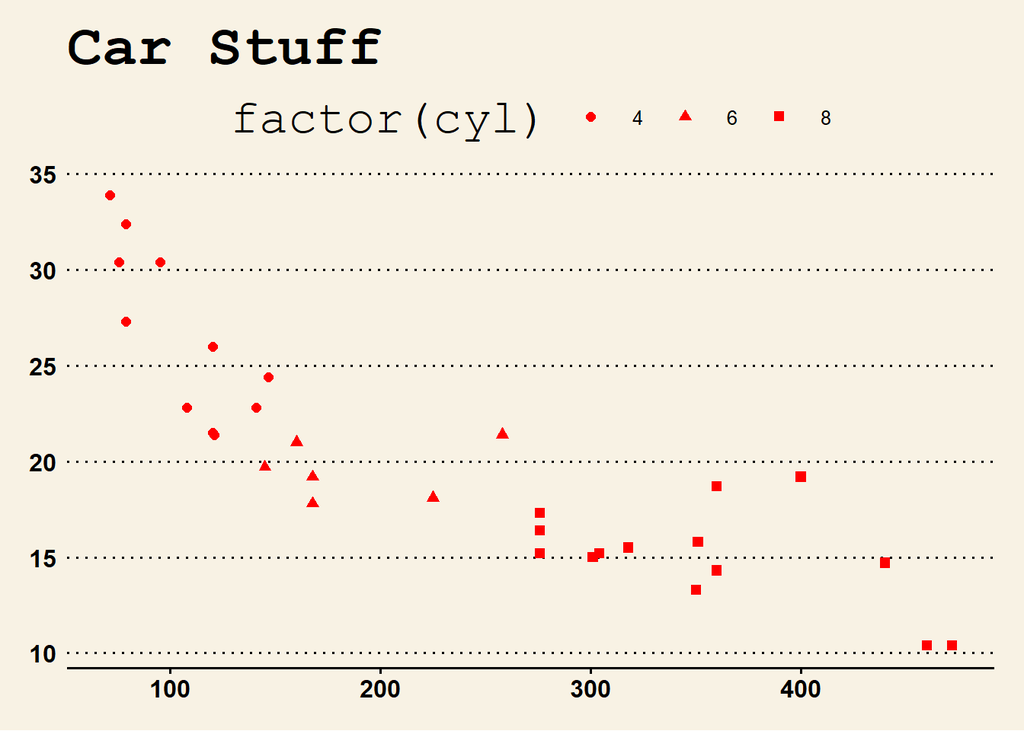

```r
#If you want even more themes you can use the ggthemes library!
#install.packages("ggthemes")
library(ggthemes)

#WSJ
ggplot(data=mtcars, aes(x = disp, y = mpg)) +
  geom_point(aes(shape = factor(cyl)), colour = "red", size = 2) +
  labs(title = "Car Stuff", x = "Displacement (cc)", y = "Miles per Gallon") +
  scale_size_continuous(name = "Cylinders") +
  theme_wsj()
```

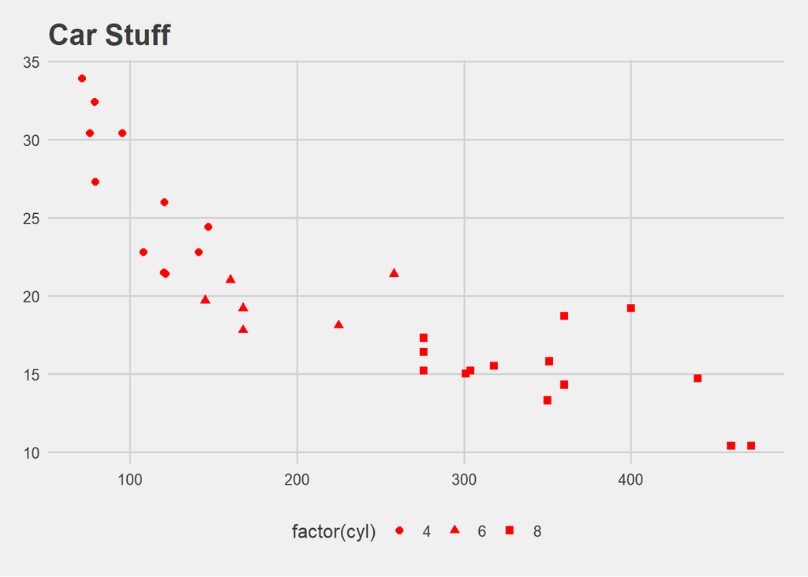

```r
#538
ggplot(data=mtcars, aes(x = disp, y = mpg)) +
  geom_point(aes(shape = factor(cyl)), colour = "red", size = 2) +
  labs(title = "Car Stuff", x = "Displacement (cc)", y = "Miles per Gallon") +
  scale_size_continuous(name = "Cylinders") +
  theme_fivethirtyeight()
```

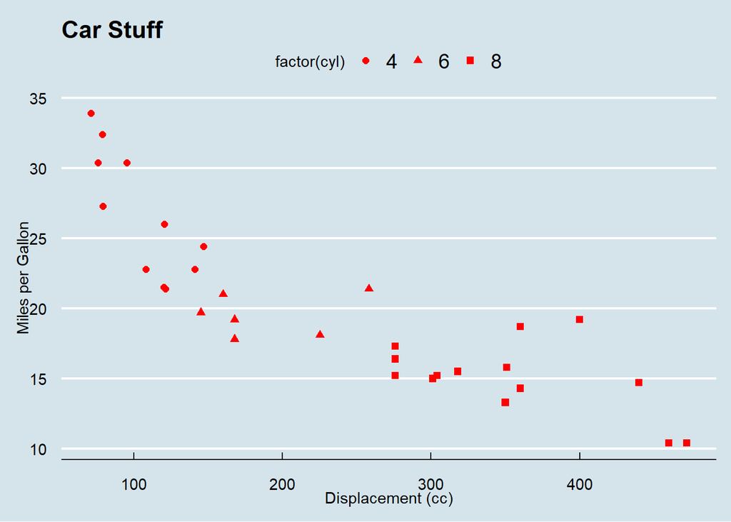

```r
#The Economist
ggplot(data=mtcars, aes(x = disp, y = mpg)) +
  geom_point(aes(shape = factor(cyl)), colour = "red", size = 2) +
  labs(title = "Car Stuff", x = "Displacement (cc)", y = "Miles per Gallon") +
  scale_size_continuous(name = "Cylinders") +
  theme_economist()
```

2. Now let’s jump back into the palmerpenguins dataset to perform some more in-depth visualization of regression models.
- Here we will evaluate the association between penguin body mass (measured in grams) and flipper length (measured in mm).
- Let’s suppose our main research question is to determine whether body mass was associated with flipper length We will set the body mass as our dependent variable and flipper length as our independent variable (or predictor of interest):

$\large E[Body\_mass_{i} | Flipper\_length_{i}] = \beta_0 + \beta_1 Flipper\_length_{i} + \epsilon,$

- where $E[Body\_mass_{i} | Flipper\_length_{i}]$ denotes the expected body mass for penguin $i$ given the flipper length of penguin $i$.

```r
#We could start by plotting the association between the penguin's body mass and flipper length

mass_flipper <- ggplot(data = penguins,
                       aes(x = flipper_length_mm,
                           y = body_mass_g))+
  geom_point()

#Does there seem to be an association?


#Yes! as flipper length increases, the body mass also increases. There appears to be a positive relationship between penguin body mass and flipper length.
```

- Now, we can construct a linear regression model with body mass as the dependent variable and flipper length. as the independent variable (or predictor of interest).

```r
linear.model1 <- lm(body_mass_g ~ flipper_length_mm, data = penguins)
summary(linear.model1)
```

```
##
## Call:
## lm(formula = body_mass_g ~ flipper_length_mm, data = penguins)
##
## Residuals:
##      Min       1Q   Median       3Q      Max
## -1058.80  -259.27   -26.88   247.33  1288.69
##
## Coefficients:
##                    Estimate Std. Error t value Pr(>|t|)
## (Intercept)       -5780.831    305.815  -18.90   <2e-16 ***
## flipper_length_mm    49.686      1.518   32.72   <2e-16 ***
## ---
## Signif. codes:  0 '***' 0.001 '**' 0.01 '*' 0.05 '.' 0.1 ' ' 1
##
## Residual standard error: 394.3 on 340 degrees of freedom
##   (2 observations deleted due to missingness)
## Multiple R-squared:  0.759,  Adjusted R-squared:  0.7583
## F-statistic:  1071 on 1 and 340 DF,  p-value: < 2.2e-16
```

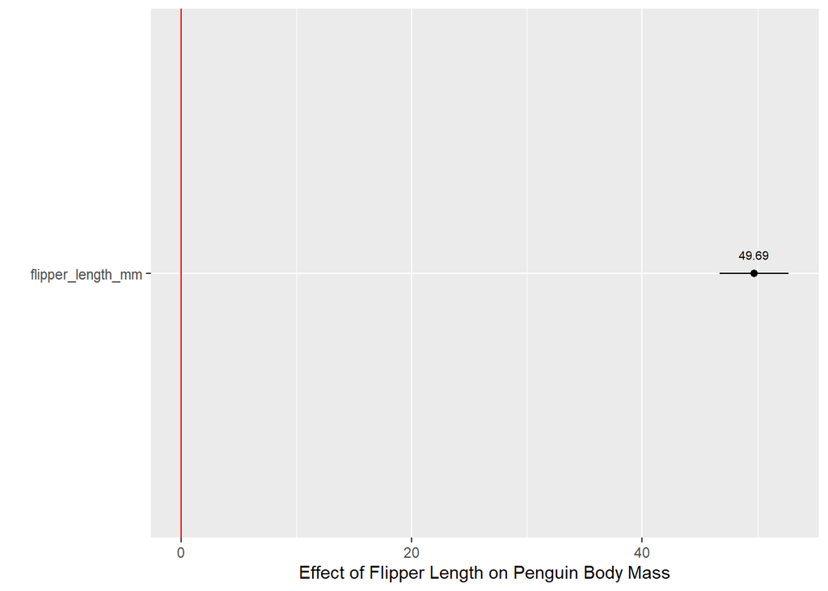

```r
#Using the broom package to tidy the model data and format into a more easily usable form.
temp_lm = broom::tidy(linear.model1, se = 'standard', conf.int = TRUE,conf.level = 0.95) %>%
  filter(term=="flipper_length_mm")


#Visualize the results in a coefficient plot
Penguin_results <- ggplot(data=temp_lm, aes(x=term, y=estimate)) +
    geom_hline(yintercept=0, color="red", linewidth=.5) +
    geom_errorbar(aes(ymin=conf.low, ymax=conf.high, width=0), size=.5, position=position_dodge(width=0.5)) +
    geom_point(aes(y=estimate), size=1.75, position = position_dodge(width=0.5)) +
    ylab("Effect of Flipper Length on Penguin Body Mass") +
    xlab("")+
    coord_flip()+
  geom_text(aes(y=estimate,label=round(estimate, digits=2)), size=2.5, vjust=-1.5, position = position_dodge(width=.2))
Penguin_results
```

```r
#Okay great so huge effect! But what about confounders? Perhaps the penguins species is also important.
```

- Lets again plot it but this time break out the results by species.

```r
mass_flipper_species <- ggplot(data = penguins,
                       aes(x = flipper_length_mm,
                           y = body_mass_g)) +
  geom_point(aes(color = species,
                 shape = species),
             size = 3,
             alpha = 0.8) +
  scale_color_manual(values = c("darkorange","purple","cyan4")) +
  labs(title = "Flipper length and body mass",
       x = "Flipper length (mm)",
       y = "Body mass (g)",
       color = "Penguin species",
       shape = "Penguin species")

#Definitely seems like species could be important to capture in our model. So let's add to our current model by including a confounder.
```

Now our model looks like this.

$\large E[Body\_mass_{i} | Flipper\_length_{i}], Species_{i}] = \beta_0 + \beta_1 Flipper\_length_{i}+ \beta_2 Species_{i} + \epsilon$

- where $E[Body\_mass_{i} | Flipper\_length_{i}], Species{i}]$ denotes the expected body mass for penguin $i$ given the flipper length of penguin $i$ and controlling for species of the penguin $i$.

```r
linear.model2 <- lm(body_mass_g ~ flipper_length_mm+species, data = penguins)
summary(linear.model2)
```

```
##
## Call:
## lm(formula = body_mass_g ~ flipper_length_mm + species, data = penguins)
##
## Residuals:
##     Min      1Q  Median      3Q     Max
## -927.70 -254.82  -23.92  241.16 1191.68
##
## Coefficients:
##                    Estimate Std. Error t value Pr(>|t|)
## (Intercept)       -4031.477    584.151  -6.901 2.55e-11 ***
## flipper_length_mm    40.705      3.071  13.255  < 2e-16 ***
## speciesChinstrap   -206.510     57.731  -3.577 0.000398 ***
## speciesGentoo       266.810     95.264   2.801 0.005392 **
## ---
## Signif. codes:  0 '***' 0.001 '**' 0.01 '*' 0.05 '.' 0.1 ' ' 1
##
## Residual standard error: 375.5 on 338 degrees of freedom
##   (2 observations deleted due to missingness)
## Multiple R-squared:  0.7826, Adjusted R-squared:  0.7807
## F-statistic: 405.7 on 3 and 338 DF,  p-value: < 2.2e-16
```

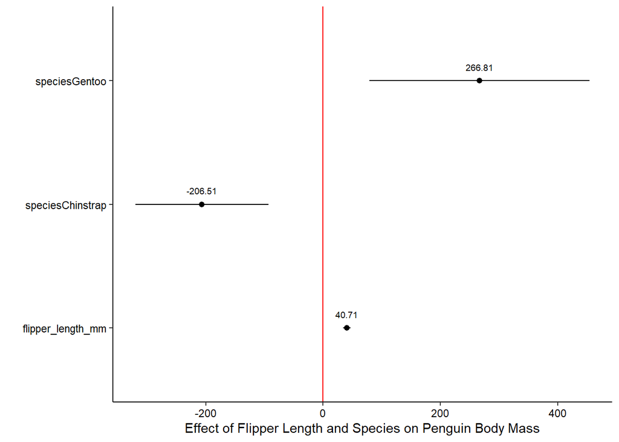

```r
#Using the broom package to tidy the model data and format into a more easily usable form.
temp_lm_2 = broom::tidy(linear.model2, se = 'standard', conf.int = TRUE,conf.level = 0.95) %>%
  filter(term!="(Intercept)")


#Visualize the results in a coefficient plot
Penguin_results_2 <- ggplot(data=temp_lm_2, aes(x=term, y=estimate)) +
    geom_hline(yintercept=0, color="red", size=.5) +
    geom_errorbar(aes(ymin=conf.low, ymax=conf.high, width=0), size=.5, position=position_dodge(width=0.5)) +
    geom_point(aes(y=estimate), size=1.75, position = position_dodge(width=0.5)) +
    ylab("Effect of Flipper Length and Species on Penguin Body Mass") +
    xlab("")+
    coord_flip()+
  geom_text(aes(y=estimate,label=round(estimate, digits=2)), size=2.5, vjust=-1.5, position = position_dodge(width=.2))+
  plot_theme

Penguin_results_2
```

- Okay great, but what if we want to visualize substantive effects? For this we can use our old friend predict()!

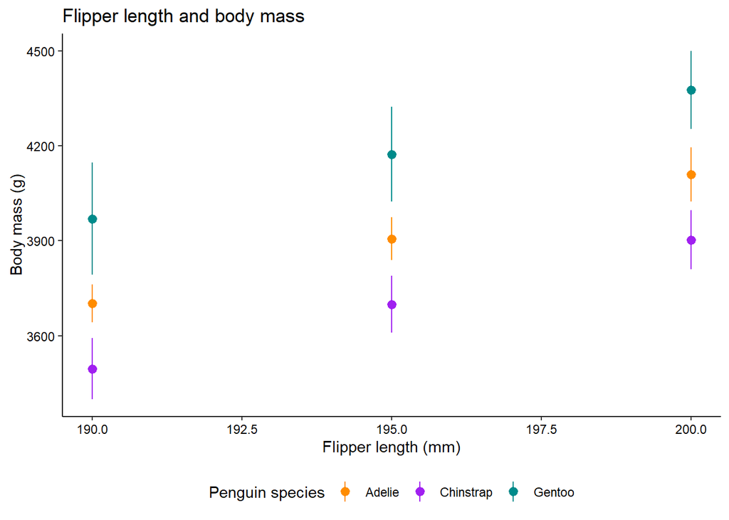

```r
newData <- expand.grid(flipper_length_mm = seq(190, 200, by = 5),
                       species=c("Adelie","Chinstrap","Gentoo"))

plotData <- as.data.frame(predict(linear.model2, newdata=newData, interval='confidence'))

#Pulling it all together
int_dat <- data.frame(newData, plotData)

subeffects_plot <- ggplot(int_dat, aes(x=flipper_length_mm, y=fit, ymin=lwr, ymax=upr,color=species)) +
        geom_pointrange() +
 scale_color_manual(values = c("darkorange","purple","cyan4")) +
  labs(title = "Flipper length and body mass",
       x = "Flipper length (mm)",
       y = "Body mass (g)",
       color = "Penguin species",
       shape = "Penguin species")+
  plot_theme

subeffects_plot
```

## Facets

- Using facets lets you create multi-panel plots based off a given variable. There are two different ggplot functions to use to facet.
1. facet_wrap() “wraps” a 1d ribbon of panels into 2d. Essentially, creating a square grid of panels, with rows and columns defined by combinations of two categorical variables (even if some combinations of faceting values do not exist in data). This is most useful when you want to facet by a single variable (or two)

```r
carsplot_facet <- ggplot(data = mtcars, aes(x = disp, y = mpg)) +
  geom_point(aes(colour = cyl), size = 2) +
  labs(title = "Car Stuff", x = "Displacement (cc)", y = "Miles per Gallon") +
  scale_colour_continuous(name = "Cylinders")+
  theme_bw()+
  facet_wrap(~ am)
```

2. facet_grid() forms a matrix of panels defined by row and column faceting variables, creating panels based on observed combinations of values in faceting variables.

```r
#facet_grid(.~variable) will return facets equal to the levels of variable distributed horizontally
#facet_grid(variable~.) will return facets equal to the levels of variable distributed vertically.

carsplot_facet_2 <- ggplot(data = mtcars, aes(x = disp, y = mpg)) +
  geom_point(aes(colour = cyl), size = 2) +
  labs(title = "Car Stuff", x = "Displacement (cc)", y = "Miles per Gallon") +
  scale_colour_continuous(name = "Cylinders")+
  theme_bw()+
  facet_grid(vs ~ am)

carsplot_facet_3 <- ggplot(data = mtcars, aes(x = disp, y = mpg)) +
  geom_point(aes(colour = cyl), size = 2) +
  labs(title = "Car Stuff", x = "Displacement (cc)", y = "Miles per Gallon") +
  scale_colour_continuous(name = "Cylinders")+
  theme_bw()+
  facet_grid(am ~ .)

carsplot_facet_4 <- ggplot(data = mtcars, aes(x = disp, y = mpg)) +
  geom_point(aes(colour = cyl), size = 2) +
  labs(title = "Car Stuff", x = "Displacement (cc)", y = "Miles per Gallon") +
  scale_colour_continuous(name = "Cylinders")+
  theme_bw()+
  facet_grid(. ~ am)
```

## Interaction analysis

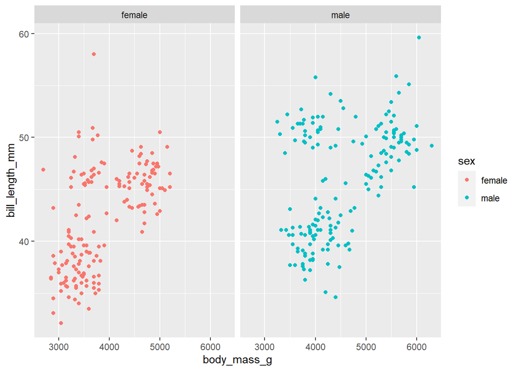

```r
#First let's plot the raw data to see if there's anything there.
penguins %>%
  # drop rows with missing data
  drop_na(sex) %>%
  ggplot(aes(x = body_mass_g, y = bill_length_mm, color = sex)) +
  geom_point() +
  facet_wrap(~ sex)
```

```r
penguin_interact<-lm(bill_length_mm~body_mass_g*sex,data=penguins)

tidy_penguin_interact = broom::tidy(penguin_interact, se = 'standard', conf.int = TRUE,conf.level = 0.95)

#Next we'll use ggpredict to get the marginal effects for the main effects and the interaction term.
#There are a ton of different packages that do similar things make_predictions from jtools is also great.

y_hat <- ggpredict(penguin_interact, terms = c("body_mass_g", "sex"))

#This returns predicted values of the dv
y_hat
```

| x | predicted | std.error | conf.low | conf.high | group |
| --- | --- | --- | --- | --- | --- |
| 2600 | 36.69606 | 0.7332219 | 35.25897 | 38.13315 | female |
| 2600 | 39.53392 | 0.9040350 | 37.76205 | 41.30580 | male |
| 2800 | 37.55180 | 0.6440173 | 36.28955 | 38.81405 | female |
| 2800 | 40.18365 | 0.8247556 | 38.56716 | 41.80014 | male |
| 3000 | 38.40755 | 0.5595024 | 37.31094 | 39.50415 | female |
| 3000 | 40.83338 | 0.7470047 | 39.36928 | 42.29748 | male |
| 3200 | 39.26329 | 0.4821495 | 38.31829 | 40.20829 | female |
| 3200 | 41.48311 | 0.6713135 | 40.16736 | 42.79886 | male |
| 3400 | 40.11903 | 0.4159737 | 39.30374 | 40.93433 | female |
| 3400 | 42.13284 | 0.5984641 | 40.95987 | 43.30581 | male |

[output cut: 30 more lines]

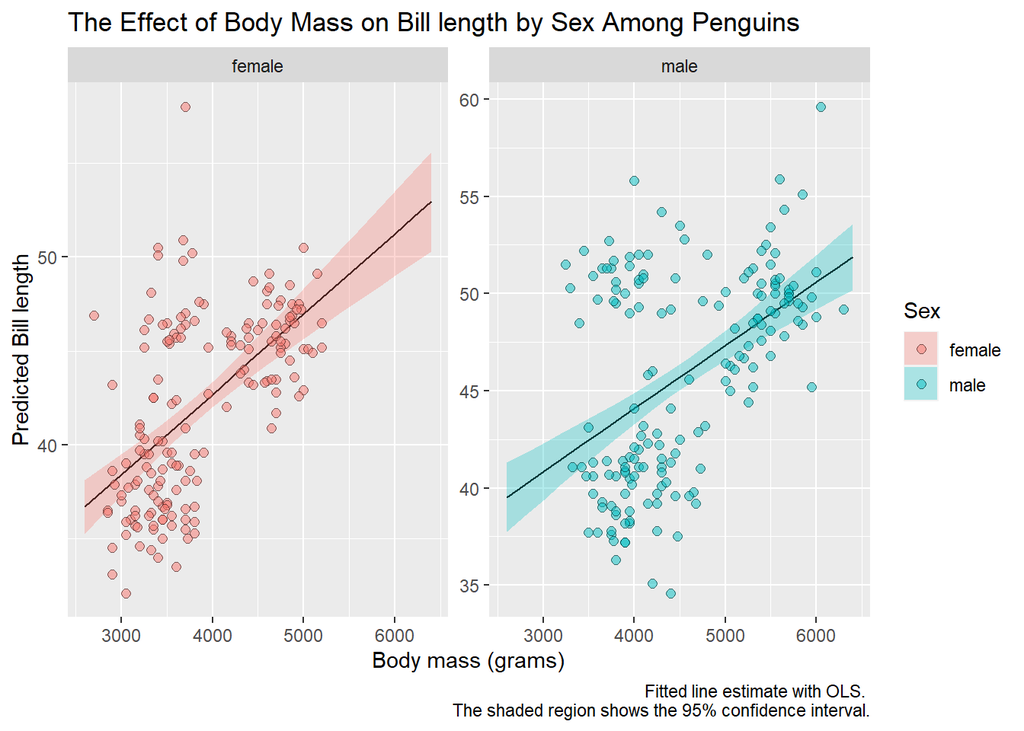

```r
#Plotting interaction effects

  #First extracting data from the model
model_data <- penguin_interact$model
  #Next, rename group to sex
y_hat <-
  y_hat %>%
  rename(sex = group)


#Plotting
ggplot(data = y_hat, aes(x = x, y = predicted, fill = sex)) +
  #plot the fitted line
  geom_line() +
  #plot the confidence intervals
  geom_ribbon(aes(ymin = conf.low, ymax = conf.high), alpha = 0.3) +
  #plot the model data
  geom_point(data = model_data, aes(x = body_mass_g, y = bill_length_mm),
             size = 2, shape = 21, alpha = 0.5) +
  facet_wrap(~ sex, scales = "free") +
  labs(title = "The Effect of Body Mass on Bill length by Sex Among Penguins",
       x = "Body mass (grams)",
       y = "Predicted Bill length",
       fill = "Sex",
       caption = "Fitted line estimate with OLS. \n The shaded region shows the 95% confidence interval.")
```

# Part 3: **Exercise** LM practice

1. Use the msleep dataset to model how body weight (bodywt) and brain weight (brainwt) influences total REM sleep (sleep_rem).
2. Then create a model including an additional predictor (of your choice).
3. Create a coefficient plot of the results of the two models and compare them.

```r
glimpse(msleep)
```

```
## Rows: 83
## Columns: 11
## $ name         <chr> "Cheetah", "Owl monkey", "Mountain beaver", "Greater shor…
## $ genus        <chr> "Acinonyx", "Aotus", "Aplodontia", "Blarina", "Bos", "Bra…
## $ vore         <chr> "carni", "omni", "herbi", "omni", "herbi", "herbi", "carn…
## $ order        <chr> "Carnivora", "Primates", "Rodentia", "Soricomorpha", "Art…
## $ conservation <chr> "lc", NA, "nt", "lc", "domesticated", NA, "vu", NA, "dome…
## $ sleep_total  <dbl> 12.1, 17.0, 14.4, 14.9, 4.0, 14.4, 8.7, 7.0, 10.1, 3.0, 5…
## $ sleep_rem    <dbl> NA, 1.8, 2.4, 2.3, 0.7, 2.2, 1.4, NA, 2.9, NA, 0.6, 0.8, …
## $ sleep_cycle  <dbl> NA, NA, NA, 0.1333333, 0.6666667, 0.7666667, 0.3833333, N…
## $ awake        <dbl> 11.9, 7.0, 9.6, 9.1, 20.0, 9.6, 15.3, 17.0, 13.9, 21.0, 1…
## $ brainwt      <dbl> NA, 0.01550, NA, 0.00029, 0.42300, NA, NA, NA, 0.07000, 0…
## $ bodywt       <dbl> 50.000, 0.480, 1.350, 0.019, 600.000, 3.850, 20.490, 0.04…
```

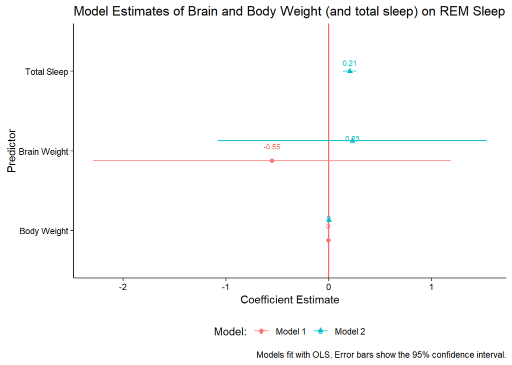

```r
#Creating model 1
model1 <- lm(sleep_rem ~ bodywt + brainwt, data = msleep)

#Tidying model 1
model1_tidy<-broom::tidy(model1, se = 'standard', conf.int = TRUE,conf.level = 0.95) %>%
  mutate(model = "Model 1")

#Creating model 2
model2 <- lm(formula = sleep_rem ~ bodywt + brainwt + sleep_total, data = msleep)

#Tidying model 2
model2_tidy<-broom::tidy(model2, se = 'standard', conf.int = TRUE,conf.level = 0.95) %>%
  mutate(model = "Model 2")

#Combine results into a single dataframe
sleep_results <- bind_rows(model1_tidy, model2_tidy) %>%
  filter(term!="(Intercept)")

#Plotting (make sure to assign color and shape to the model variable in the ggplot call)
sleep_results_plot <- ggplot(data=sleep_results, aes(x=term, y=estimate,
           color = model, shape = model)) +
    geom_hline(yintercept=0, color="red", size=.5) +
    geom_errorbar(aes(ymin=conf.low, ymax=conf.high, width=0), linewidth=.5, position=position_dodge(width=0.5)) +
    geom_point(aes(y=estimate), size=1.75, position = position_dodge(width=0.5)) +
  labs(title = "Model Estimates of Brain and Body Weight (and total sleep) on REM Sleep",
       x = "Predictor",
       y = "Coefficient Estimate",
       caption = "Models fit with OLS. Error bars show the 95% confidence interval.",
       color = "Model:",
       shape = "Model:") +
   scale_x_discrete(labels = c("Body Weight", "Brain Weight", "Total Sleep"))+
  coord_flip()+
  geom_text(aes(y=estimate,label=round(estimate, digits=2)), size=2.5, vjust=-1, position = position_dodge(width=.2))+
  plot_theme


sleep_results_plot
```